# TAP2 Factorial Design

## Task One

**Hypothesis**

At follow-up participants’ stress will be predicted by the programme to which they were assigned (trial_arm) but this effect will be moderated by their job role. Specifically, they predicted that the effect of trial_arm would be stronger in (1) medical roles compared to management and support worker roles; (2) management roles compared to support worker roles.

**The design**

As there are two independent variables that predict a dependent variable, a General Linear Model using a 2-way Factorial design will be fit.

**Summary statistics**

Initially summary statistics of both independent variables (trial group and job role) will be reported, including the means and confidence intervals. This will illustrate the initial relationship between the independent variables and the dependent variables. The means will demonstrate how stress scores differ across the groups and the confidence intervals will illustrate how much the scores vary. I will be looking directly to see if there are any obvious patterns, for example, are the means between the groups similar? are they dissimilar? Is there are groups that are vastly different to the others? This will allow an initial understanding of the data.

Furthermore, the means and confidence intervals will be plotted in order to visualize the data. This will allow a visual comparison of the means in each job role and in each trial group. I will be looking to see whether job groups vary in stress score, whether trial groups vary in stress scores and finally if stress scores vary between trial groups within a job role.

**Fit the model**

*Use lm() function*

The factorial model will then be fit using the lm() function. This function will be chosen as its a more flexible choice that allows analysis to obtain diagnostic plots (that your not able to obtain using the afex() package). Furthermore, the lm() function does not affect the parameter estimates, meaning b is more accurate.

*Set manual contrasts*

*Report overall model summary*

The overall summary will then be reported for the model (including the trial group, job role and the interaction between the trial group and job role). This will show whether the interaction between both independent variables (trial group and job role) are statistically significant. If p<0.05 then the interaction effect is significant therefore supporting the hypothesis, if p>0.05 then the interaction effect is insignificant.

*Report parameter estimates*

The parameter estimates will then be reported in order to gain the raw effect sizes of the interactions between the effect of job role (for medical vs non medical and management vs support worker) on stress to see if scores are significantly different in for the trial groups (psycho-social and mindful). Within this data i will be looking to see if the interaction effects are statistically significant, if they are this will support the hypothesis. This will be formally tested using a simple effect analysis in order to solidify the understanding of the data.

*Report the simple effects analysis*

This will formally test the effect of role within each trial group separately and also test the effect of trial group within each role separately.

*Report the effect sizes*

The final part of fitting the model requires to test the effect sizes in order to gain information regarding how much the interaction effect explains the variance in the dependent variable (stress score). Omega squared with be reported rather than eta squared as omega squared is less biased.

**Test assumptions**

In order to test the assumptions of homogeneity, normality and linearity diagnostic plots will be produced. Homogeneity will be tested with the use of Residuals vs Fitted plot and Scale-Location plot. To assume homogeneity I will be looking for a straight line with a vertical spread of points along the x-axis. If there is a substantial curve of the line or the data shows a clear funnel shape this would suggest hetroscadascity.

A Normal Q-Q plot will then be plotted to determine if the data set is well modeled by a normal distribution. I will be looking to see if the Q-Q plot is skewed or tailed as this would suggest the sample is not normally distributed, perhaps suggesting potential influential cases.

Finally cooks distance will be plotted in order to establish whether there are any influential cases or outliers. Here, i will be looking to see if any cases are above the threshold of 1 as this would suggest influential cases/ outliers. If any outliers are identified a robust model will be fit in order to evaluate whether they have caused bias in the data set.

**Robust Model**

If there was any suggestion of bias in the Cooks distance measurement a robust model will be fit in order to understand whether it has caused bias in the OLS model. The summary statistics will report “the test for bias” if the p-values for this test is non-significant this will tell me that the bias in the OLS model is not problematic. Furthermore, the robust model parameters should have similar b estimates to the OLS and the significance should also remain similar. If not, this would suggest the OLS model has been biased.

**Bayes Factor**

Bayes Factor will report the probability of the data given the alternative hypothesis relative to the probability of the data given the null. Bayes Factor will indicate whether I should change my beliefs about the alternative hypothesis. For example, a number above 3 is evidence to support the alternative hypothesis, but a value below 0.3 is evidence for the null hypothesis. Bayes Factor will be calculated for the individual effect of role, the effect of role and trial group and finally the combined effect of role and trial group. The effect i will focus on will be the effect of role and trial group as well as the combined effect as this relates directly to the hypothesis. These values will be used to form the final conclusion of the analysis.

## Task Two

**Description of the General Linear Model**

The general linear model is a statistical technique that investigates the linear relationship between one dependent variable and one or more independent variable(s). The GLM is the foundation for several statistical tests including; ANOVA, Regressions analysis and correlation analysis. The formula for the General Linear Model is stated below:

$$\text{Y}_i= (\text{model}_i)+e_1 \\
\text{Outcome}_i= b_0+b_1\text {predictor}_{1i}+e_1$$

• Y stands for the dependent variable (the variable the model aims to predict)

• b<sub>0</sub> stands for the intercept (which is always constant)

• b<sub>1</sub> stands for a weight or a slope, otherwise refered to as the coefficient. This determines how much weight one variable contributes to the model.

• e stand for the error in the model.

**The hypothesis:**

*At follow-up participants’ stress will be predicted by the programme to which they were asssigned (trial_arm) but this effect will be moderated by their job role. Specifially, they predicted that the effect of trial_arm would be stronger in (1) medical roles compared to management and support worker roles; (2) management roles compared to support worker roles*.

Therefore, as the report has two independent variables, where trial is moderated by job role, that predicts one dependent variable (stress score), a 2-way factorial design is best suited. This design allows researchers to assess the interaction and allows the effects of a factor (trial group) to be estimated at several levels of another factor (job role). This will result in a conclusion that has fully investigated all possible combinations of the levels of the categorical predictors.

**The equation for the factorial design**

$$\text{stress}_i = b_0+b_1\text{trial}_i+b_2\text{role}_i+b_3\text{trial x role}_i+e_i$$

**The assumptions of the model**

As the current model is a linear model there are three main assumptions that need to be met. The first is linearity and additivity, linearity is the assumption that the relationship between the dependant variable (stress score) and the independant variables (trial group and job role) is linear. This can be tested with the use of plots. Additivity is the assumption that when there are several independant variables in the model we assume that the combined effect of those variables are “additive”, in other words that the effect of one variable adds to the effect of the other variable.

Secondly, the population errors are assumed to be “spherical”. This is broken down into two conditions; population errors are assumed to have homoscedacisty and population errors are assumed to be independant/uncorrelated. The first condition means that the variance in errors is the same at all values of the predictors (trial and job role). The second condition relates to the assumption that errors should be un-influenced.

The last assumption is the normality of the sampling distribution, which refers to the assumption that the residuals of the model are normally distributed, or that the sampling distribution of the parameter is normally distributed.

## Task Three

### Preparing data for analysis.

**Loaded packages**

```r
library(tidyverse)
library(ggfortify)
```

**Loaded data and filtered tibble**

```r
mindful_tib <- here::here("data/tap_mindfulness.csv")%>%
  readr::read_csv()%>%
  dplyr::mutate(
    role = forcats::as_factor(role) %>% forcats::fct_relevel("Medical", "Management", "Support workers"),
    trial_arm = forcats::as_factor(trial_arm)
    )

mindful_tib <- mindful_tib %>%
  dplyr::filter(time == "Follow-up")
```

### Exploring data

**Reporting the mean and confidence intervals of stress scores**

```r
mindful_tib %>%
  dplyr::group_by(role, trial_arm) %>%
  dplyr::summarize (
    mean = mean (stress, na.rm = TRUE),
    '95% CI lower' = mean_cl_normal(stress)$ymin,
    '95% CI upper' = mean_cl_normal(stress)$ymax
    )%>%
  knitr::kable(digits = 2, caption = "Table 1: Summary statistics")
```

Table 1: Summary statistics

| role | trial_arm | mean | 95% CI lower | 95% CI upper |
| --- | --- | --- | --- | --- |
| Medical | Psychosocial information | 21.55 | 20.18 | 22.93 |
| Medical | Mindfullness | 16.99 | 15.49 | 18.48 |
| Management | Psychosocial information | 17.64 | 12.23 | 23.04 |
| Management | Mindfullness | 20.00 | 13.26 | 26.74 |
| Support workers | Psychosocial information | 17.62 | 16.05 | 19.18 |
| Support workers | Mindfullness | 17.14 | 15.67 | 18.61 |

Note that the means of stress scores for the roles management and support worker under both trial groups are fairly similar. However, the mean stress score for medical roles differ by a large amount in each trial group.

**Plot to visualize the means and confidence intervals of stress scores**

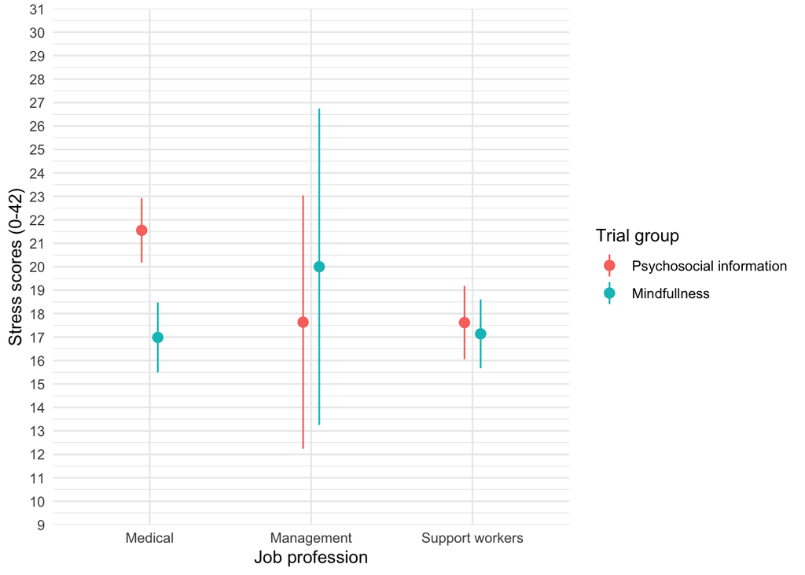

```r
ggplot2::ggplot(mindful_tib, aes(x = role, y = stress, colour = trial_arm)) +
  stat_summary(fun.data = "mean_cl_normal", geom = "pointrange", position = position_dodge(width = 0.2)) +
  coord_cartesian(ylim = c(10,30)) +
  scale_y_continuous(breaks = 0:40) +
  labs(x = "Job profession", y = "Stress scores (0-42)", colour = "Trial group") +
  theme_minimal()
```

Note, the mean stress scores of those with a medical job role clearly differ in each trial group more so than that of the management and support worker groups. However, upon comparing the management and support worker groups, it appears that management role differs in stress score within trial groups more than the support worker role.

This initial relationships supports the hypothesis that the effect of trial group would be stronger in medical roles compared to non-medical roles and stronger in management roles compared to support worker roles.

### Fitting the GLM (Factorial design)

**Setting manual contrasts**

```r
med_vs_non <-c(-2/3,1/3,1/3)
manage_vs_support <- c(0, -1/2, 1/2)
contrasts (mindful_tib$role) <- cbind(med_vs_non, manage_vs_support)
contrasts (mindful_tib$trial_arm) <- c(-1/2,1/2)
mindful_lm <- lm(stress ~ trial_arm*role, data =mindful_tib)
```

**Reporting the models statistics**

**Overall model summary**

```r
car::Anova(mindful_lm, type = 3)%>%
  knitr::kable(digits = 2, caption = "Table 2: Overall model summary")
```

Table 2: Overall model summary

|  | Sum Sq | Df | F value | Pr(>F) |
| --- | --- | --- | --- | --- |
| (Intercept) | 57617.75 | 1 | 806.44 | 0.00 |
| trial_arm | 33.73 | 1 | 0.47 | 0.49 |
| role | 453.50 | 2 | 3.17 | 0.04 |
| trial_arm:role | 664.55 | 2 | 4.65 | 0.01 |
| Residuals | 37723.85 | 528 | NA | NA |

These values support the hypothesis that stress is predicted by the trial group moderated by job role.

**Parameter estimates**

```r
broom::tidy(mindful_lm)%>%
  knitr::kable(digits = 2, caption= "Table 3: Parameter estimates")
```

Table 3: Parameter estimates

| term | estimate | std.error | statistic | p.value |
| --- | --- | --- | --- | --- |
| (Intercept) | 18.49 | 0.65 | 28.40 | 0.00 |
| trial_arm1 | -0.89 | 1.30 | -0.69 | 0.49 |
| rolemed_vs_non | -1.17 | 1.07 | -1.10 | 0.27 |
| rolemanage_vs_support | -1.44 | 1.89 | -0.76 | 0.45 |
| trial_arm1:rolemed_vs_non | 5.51 | 2.14 | 2.58 | 0.01 |
| trial_arm1:rolemanage_vs_support | -2.84 | 3.78 | -0.75 | 0.45 |

trial_arm1:role1. The p-value is statistically significant indicating that the effect of job role (medical vs non medical) on stress scores is significantly different for the psycho-social and mindful trial groups.

trial_arm1:role2. The p-value is statistically insignificant indicating that the effect of job role (management vs support worker) on stress scores is insignificantly different for the psycho-social and mindful trial groups.

**Simple effects analysis**

```r
emmeans::joint_tests(mindful_lm, "role")%>%
  knitr::kable(digits = 2, caption ="Table 4: Simple effects analysis for job roles")
```

Table 4: Simple effects analysis for job roles

| model term | role | df1 | df2 | F.ratio | p.value |
| --- | --- | --- | --- | --- | --- |
| trial_arm | Medical | 1 | 528 | 20.80 | 0.00 |
| trial_arm | Management | 1 | 528 | 0.43 | 0.51 |
| trial_arm | Support workers | 1 | 528 | 0.18 | 0.67 |

Note p <0.001 for the medical job role. Suggesting a medical role has a significant effect on the dependent variable (stress score) within the trial groups (mindful and psycho-social).

p-value for the management role (p=0.51) and the support worker role (p=0.67) are both insignificant p>0.05 threshold. Suggesting that a management role and a support worker role has an insignificant effect on the dependent variable (stress score) within the trial group.

In summary it seems like the trial group (mindful and psycho-social) is more significant for the medical job role than for the management or support worker role. This supports the hypothesis that the effect of trial group will be stronger in medical roles vs non medical roles, as the medical role has a significant effect on stress and the non-medical roles (management and support worker) have insignificant effects on stress.

```r
emmeans::joint_tests(mindful_lm, "trial_arm")%>%
  knitr::kable(digits = 2, caption= "Table 5: Simple effects analysis for trial groups")
```

Table 5: Simple effects analysis for trial groups

|  | model term | trial_arm | df1 | df2 | F.ratio | p.value |
| --- | --- | --- | --- | --- | --- | --- |
| 1 | role | Psychosocial information | 2 | 528 | 7.29 | 0.00 |
| 3 | role | Mindfullness | 2 | 528 | 0.65 | 0.52 |

Note the p-value for the psycho-social trial group (p= 0.0008). Suggesting the psycho-social group within all job roles has a significant effect p<0.001 on the dependent variable (stress score).

The p-value for the mindful trial group (p= 0.52). Suggesting the mindful group within all job roles has a insignificant effect p>0.05 on the dependent variable (stress score).

**Effect sizes**

```r
car::Anova(mindful_lm, type = 3) %>%
  effectsize::omega_squared(., ci = 0.95)%>%
  knitr::kable(digits = 4, caption = "Table 6: Effect sizes (Omega squared)")
```

Table 6: Effect sizes (Omega squared)

|  | Parameter | Omega2_partial | CI | CI_low | CI_high |
| --- | --- | --- | --- | --- | --- |
| 2 | trial_arm | -0.0010 | 0.95 | 0e+00 | 1 |
| 3 | role | 0.0081 | 0.95 | 0e+00 | 1 |
| 4 | trial_arm:role | 0.0135 | 0.95 | 8e-04 | 1 |

The omega squared values for role (0.008) shows that the job role explains 0.8% of the variance in the dependent variable (stress score).

The omega squared values for trial_arm x role interaction (0.0135) explains 1.4% of the variance in the dependent variable (stress score).

### Testing assumptions

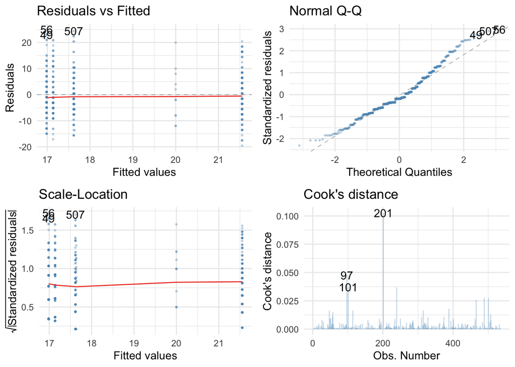

```r
ggplot2::autoplot(mindful_lm,
                  which = c(1:4),
                  colour = "#5c97bf",
                  smooth.colour = "#ef4836",
                  alpha = 0.3,
                  size = 0.5) +
  theme_minimal()
```

**Interpreting Residual vs Fitted and Scale-Location graphs.**

(Residuals vs Fitted) The line lies flat along 0. The vertical spread of points are is similar as you move along the x-axis. Therefore, the residuals show homogeneity.

(Scale-Location) The vertical spread of points are similar as you move along the x-axis. Also showing homogeneity.

**Interpreting Normal Q-Q plot**

The plots on the Q-Q plot only deviate slightly from the lines at the extremes. Potentially suggesting a slightly tailed Q-Q plot, however this is not drastic enough to violate normality. Therefore, we can assume normality.

**Interpreting Cooks distance**

### Bayes Factor

```r
role_bf <- BayesFactor::lmBF(formula = stress~ role, data = mindful_tib)

trial_bf <- BayesFactor::lmBF(stress~ role + trial_arm, data = mindful_tib)

int_bf <- BayesFactor::lmBF(formula = stress~ role + trial_arm + role:trial_arm, data = mindful_tib)

role_bf
```

```
## Bayes factor analysis
## --------------
## [1] role : 1.154069 ±0.02%
##
## Against denominator:
##   Intercept only
## ---
## Bayes factor type: BFlinearModel, JZS
```

```r
trial_bf/role_bf
```

```
## Bayes factor analysis
## --------------
## [1] role + trial_arm : 32.72878 ±5.43%
##
## Against denominator:
##   stress ~ role
## ---
## Bayes factor type: BFlinearModel, JZS
```

```r
int_bf/trial_bf
```

```
## Bayes factor analysis
## --------------
## [1] role + trial_arm + role:trial_arm : 4.453829 ±6.07%
##
## Against denominator:
##   stress ~ role + trial_arm
## ---
## Bayes factor type: BFlinearModel, JZS
```

### Conclusion

The aim of the report was to test the following hypothesis:

**at follow-up participants’ stress will be predicted by the programme to which they were asssigned (trial_arm) but this effect will be moderated by their job role**.

**Specifically, they predicted that the effect of trial_arm would be stonger in (1) medical roles compared to management and support worker roles**

The reported model parameter estimates suggested that the effect of job role (medical vs management and support worker) is significantly different for each trial group (psycho-social and mindful). This supports hypothesis (1) as the values shows the effect of job role (medical vs non medical) on stress is different within the trial groups.

The simple effect analysis further supports this as the p-values for the medical role has a significant effect on stress but the p-values for management and support worker do not. Therefore suggesting medical roles have a stronger effect.

**(2) management roles compared to support worker roles**.

However, the parameter estimates for management vs support worker do not support hypothesis (2). As there is no statistical significance to the difference in stress scores for both of the job roles (management and support worker).

The simple effects analysis further supports this as p-value show that the support worker role and the management role has an insignificant effect on stress. Therefore suggesting that there’s is little statistical significance that the management role, moderated by trial group, has a larger effect on stress compared to the support worker role, as both effects are insignificant.

### Reflective statement

The first challenge I faced at the beggining of this TAP was setting the levels for the the categorical factors. I looked at the overview section for discovr 13 in order to get a grasp, but since i hadn’t set levels since discovr 1 I found it difficult to get my head round it. I decided to go back to discovr 1 and refresh my memory on the basics of setting levels for factors. I finally got a grasp of the code using forcats:: but for some reason it still was not working. I looked through my codes to decipher what the issue was, eventually it clicked that i had tried to create the levels before i had downloaded the data file. Thankfully, this was an easy issue to fix and once the code was re-ordered i was able to continue to combat the rest of the report. As i spent some time trying to decipher why the code was not working, ordering the code tactfuly has now become a rule of thumb in order to avoid unnecessary error messages in the future.

Another challenge I faced during the last TAP was how to order the analysis. For example, in TAP 1 the clarity of my analysis plan represented how i felt about the content- confused. In order to avoid feeling lost during TAP 2 I thoroughly went through each piece of material available. I made me way through each tutorial at least once and went through the more recent tutorials (9-14) two times making notes on each step necessary for different GLM designs. Furthermore, i also made my way through the suggested reading focusing on what each model meant, for example, what the bayesian model represented and how it fits into the understanding of the data. Collectively, all this information finally clicked together and gave me a much clearer understanding of how to execute an effective analysis plan. This was supported by my relative calmness when working through TAP 2 and as i had made so many notes regarding the order and meaning of tests that whenever i felt confused or unsure I was able to refer back to my pre-prepared notes on each topic. In conclusion the pre-preparation made my expereince of TAP 2 much less frightening and i am proud of the how much improvement i have made within such a short space of time.